# Module 10 Lecture - Emotion and Motivation

Introductory Psychology

Quinton Quagliano, M.S., C.S.P

Department of Psychology

# 1 Overview and Introduction

Agenda

1 Overview and Introduction

2 Motivation

3 Hunger and Eating

4 Emotion

5 Conclusion

## 1.1 Textbook Learning Objectives

- Define intrinsic and extrinsic motivation
- Understand that instincts, drive reduction, self-efficacy, and social motives have all been proposed as theories of motivation
- Explain the basic concepts associated with Maslow’s hierarchy of needs
- Describe how hunger and eating are regulated
- Differentiate between levels of overweight and obesity and the associated health consequences
- Explain the health consequences resulting from anorexia and bulimia nervosa
- Explain the major theories of emotion

## 1.2 Instructor Learning Objectives

- Connect different needs with with previously covered topics such as development, humanistic psychology, biopsychology
- Understand how our physical body and structures continue to play a role in our behavior, affect, and cognition
- Start to see how psychological dysfunction can arise to clinically-concerning conditions

## 1.3 Introduction

- **Discuss: What *motivated* you to come to class / start the lecture video - why are you here, doing this?**
- Before we behave a certain way, we have to have some motivation to do so.
  - There will be several theories of motivation to memorize as part of this unit, much like how we had several theories of learning to learn
  - And our emotions tend to modify our motivation at the same time!
- Our motivation is complex and guided by many different desires, needs, and influences
  - Thus, our behavior resulting from the motivation is also not simple

# 2 Motivation

Agenda

1 Overview and Introduction

2 Motivation

3 Hunger and Eating

4 Emotion

5 Conclusion

## 2.1 Introduction

- **Motivation** is our wants and needs that direct behavior towards a certain goal. There are two types:
  - **Intrinsic motivation** is that which is not due to outside reward but is fully internal
    - E.g., I want to learn how to play the trumpet because I want to feel like I can overcome a challenge
  - **Extrinsic motivation** is that which is external and motivated by things like compensation, punishment, and reward
    - E.g., I want to work hard in school so that I can get a job that pays me a lot of money

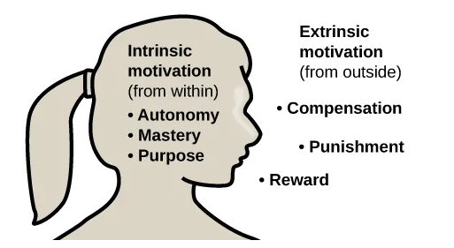

- **Discuss: What are the different reasons people go to college? Would you describe these as intrinsic or extrinsic motivation?**

## 2.2 Relationship Between Intrinsic and Extrinsic Motivation

- In general, extrinsic motivation is more fleeting, and tends to be less effective given enough time
- The **overjustification effect** is an example of this: if we are continuously given extrinsic reward for something we find intrinsically pleasing, we might lose the intrinsic value
  - E.g., I like programming as a hobbyist, but many software developers dream of being farmers
  - However, this effect doesn’t appear to always be true
- **Important: Like most things we learn, it is more complicated than one thing *always* being true**
- Evidence suggest that physical and tangible reinforcement, like money and other forms of compensation have a more negative impact on intrinsic motivation, whereas verbal reinforcement of praise has less of a harmful effect
- **Discuss: What is something you enjoy doing - but wouldn't ever want to do as a full-time job?**

## 2.3 Connection to Education

- In education, evidence suggests that students feel more intrinsic motivation to do well when they feel a sense of belonging, respect, and safety
  - This is why instructors should make efforts to keep good rapport
- **Discuss: What are the things in this class that *help* your sense of belonging? What about things that *hurt* your sense of belonging? Does one outweigh the other?**

## 2.4 Theories on Motivation

- You should be able to understand and identify the differences between the following theories

### William James’ Instinct Theory

- **Question: Which historical perspective was William James connected to in Module 1?**
- A) Structuralism
- B) Functionalism
- C) Biopsychology
- D) Behaviorism
- James’ thoughts on motivation revolved around **instinct**
  - E.g., suckling from mother, predatory-prey interactions
  - James’ was fairly radical in saying that instincts account for quite a bit of motivation

### Homeostasis Theory

- Another early view places emphasis on **homeostasis**
  - This is our body’s tendency to maintain balance in our various body systems
  - E.g., our body constantly reminding us to sleep via yawning due to the circadian rhythm of sleeping
- **Question: If our hormones are out of whack, what part of the **endocrine system** will help direct the production and management of the hormones?**
- A) Pituitary
- B) Pineal
- C) Testes
- D) Liver
- **Drive theory** posits that our motivation is a result of our body attempting to maintain homeostasis through various means
  - E.g., Eating to raise blood sugar back to normal, balanced level
- **Discuss: Other than sleep or eating, what other natural drives might we have that motivate us to behave a certain way?**

### Social Motivation

- **Social motivation** may also be very salient in our behaviors
  - This is related to our desire to be socially-accepted and seeking these 3 things:
    - Achievement, e.g., succeeding in something
    - Affiliation, e.g., being in a group
    - Intimacy, e.g., our desire to be close romantically and/or platonically to others
  - E.g., your mom saying, “If your friends jumped off a bridge…”
- We have a sense of **self-efficacy**, which is our belief we are capable of doing a certain task
  - E.g., When I need to sit down and write a lecture, I tell myself I am capable of getting it done
  - Low self-efficacy can inhibit us from actually attempting
  - E.g., If I feel like I’ll fall while ice-skating and that I won’t get the hang of it, I may resist going
- **Question: If I have a low self-efficacy I am [BLANK] likely to try a challenging task**
- A) More
- B) Less
- C) NA
- D) NA

### Maslow’s Hierarchy of Needs

- Abraham Maslow proposed a famous **hierarchy of needs**

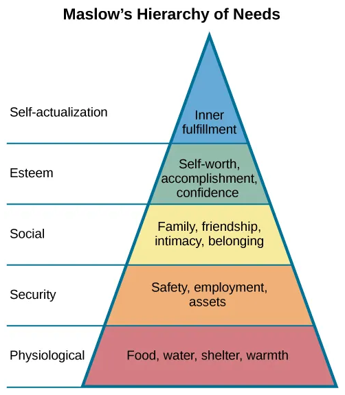

- **Question: Maslow came up briefly in module 1, what historical perspective was he a *reaction* to?**
- A) Cogntivism
- B) Behaviorism
- C) Functionalism
- D) Humanism

# 3 Hunger and Eating

Agenda

1 Overview and Introduction

2 Motivation

3 Hunger and Eating

4 Emotion

5 Conclusion

## 3.1 Introduction

- Hunger is one of our natural motivators, as it helps ensure we eat enough food to survive
- **Question: If a modern psychologist were studying the development of a sense of hunger as a means of fitness to survive, they would be best classified under:**
- A) Biopsychology
- B) Cognitive Psychology
- C) Clinical Psychology
- D) Evolutionary Psychology

## 3.2 Physiological Mechanisms

- **Discuss: Review: describe the entire process of the production of melatonin in the endocrine system, starting with the light coming in the eyes**
- Like many of our functions, e.g., sleep, it is much more complicated than it may seem!
- Signals for hunger:
  - Stomach contracts $\rightarrow$ hunger pangs/cramps
  - Chemical feeding signals sent in brain $\rightarrow$ psychological desire for food
  - Blood sugar drops $\rightarrow$ endocrine system makes chemical signals to induce hunger
- **Question: Which gland in the endocrine system controls the creation of insulin?**
- A) Kidneys
- B) Pineal
- C) Liver
- D) Pancreas
- Once the hunger is meet, we get to a point of **satiation**

## 3.3 Metabolism and Body Weight

- Body weight is complex, but does basically function on calories in vs. calories out
- However, our **metabolic rate** can be vastly different between people
  - E.g., this is why someone with “high metabolism” might appear to eat significant food with little change in their body
- One tentative explanation for our general tendency towards a certain weight is called **set-point theory**
  - However, this is not completely well-supported as a theory
- **Important: Our 'psychology' involves a lot of functions in our body as they relate to how we act!**

# 4 Emotion

Agenda

1 Overview and Introduction

2 Motivation

3 Hunger and Eating

4 Emotion

5 Conclusion

## 4.1 Introduction

- **Discuss: When was the last time you felt pure joy or peace - describe that time**
- An **emotion** is a subjective state of being. Emotions are the combination >of:
  - Experiences
  - Expression
  - Cognitive appraisal
  - Physiological responses
  - Together, these 4 things are called the **component of emotions**
- **Experiences** our the stimuli, which may be internal or external that stir emotion
  - E.g., Watching a sad movie, hearing a funny joke
- **Expressions** are how we show our emotions through verbal and nonverbal behavior
  - E.g., Tears from sadness, Raising voice in anger
- **Cognitive appraisal** is our understanding of how an emotional experience will impact us
  - E.g., I judge that being told I am getting fired will have a profoundly bad impact on my wellbeing
- **Physiological responses** is how our body responds to emotion
  - E.g., sweating, heart racing
- **Question: When I am extremely happy, I start unconsciously bouncing up and down, this action would be best described as...**
- A) Experience
- B) Expression
- C) Cognitive appraisal
- D) Physiological response
- **Important: The following sections will make often use of these terms/descriptors, so please keep them in mind!**

## 4.2 Theories of Emotion

- In the following figures and descriptions, consider the scenario where a man experience the emotion of fear from a snake
- Each of these theories differs primarily in how the different components of emotions are explained

### James-Lange Theory

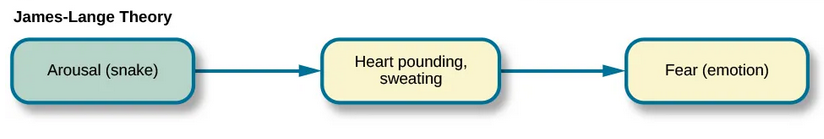

### Cannon-Bard Theory

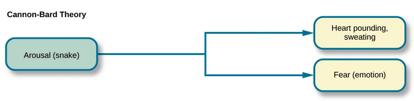

### Schachter-Singer Two-Factor Theory

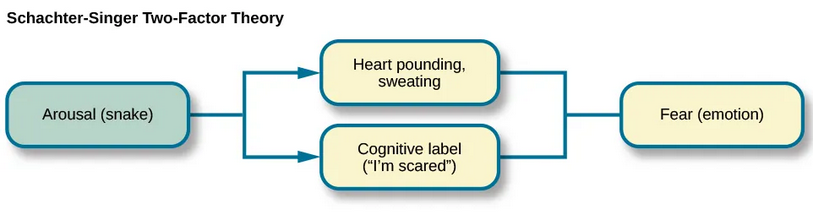

### Lazarus Cognitive-meditational Theory

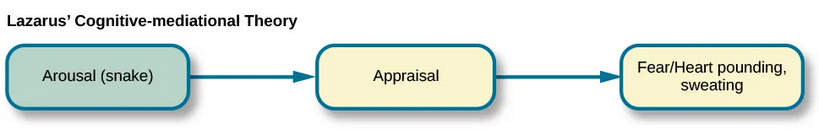

### Discriminating Between Theories

- **Question: I see a spider and begin to get tense and sweat, in turn becoming afraid. This best shows...**
- A) James-Lange Theory
- B) Cannon-Bard Theory
- C) Schachter-Singer Theory
- D) Lazarus' Cognitive-meditational Theory
- **Question: I see a spider and begin to get tense and sweat while simultaneous recognizing that I am scared of the spider, in turn becoming afraid. This best shows...**
- A) James-Lange Theory
- B) Cannon-Bard Theory
- C) Schachter-Singer Theory
- D) Lazarus' Cognitive-meditational Theory
- **Question: I see a spider and recognize it may very well be dangerous to me, in turn becoming afraid. This best shows...**
- A) James-Lange Theory
- B) Cannon-Bard Theory
- C) Schachter-Singer Theory
- D) Lazarus' Cognitive-meditational Theory

# 5 Conclusion

Agenda

1 Overview and Introduction

2 Motivation

3 Hunger and Eating

4 Emotion

5 Conclusion

## 5.1 Recap

- Motivation and emotion both have numerous theories that describe how we become motivated or emotional, respectively. You should be able to tell the differences between these theories
- Similarly, motivation and emotion both have numerous vocabulary terms associated with them to describe the individual parts!
- Hunger is an example of a natural motivation that we have, and goes to show how ‘psychological’ is a very broad term covering a lot of our bodily processes and how we react to them!

## 5.2 Lecture Check-in

- Make sure to complete any lecture check-in tasks associated with this lecture!

[figure not shown]

Module 10 Lecture - Emotion and Motivation || Introductory Psychology